# Part 5 — Explainability and uncertainty

- Show All Code
- Hide All Code
- View Source

Complete tutorial for sciModelFlowR (version 1.0.2)

Author

Walter Esfrain Pereira

Published

September 19, 2026

# 1 Explaining without confusing importance with cause

```r
field <- ler("field_yield")
v <- verdade$field_yield
no_out <- field[!field$plot_id %in% v$outlier_ids, ]

spec_p5 <- smf_experiment_spec(
  task = smf_task_spec("regression", "yield"),
  data = smf_data_spec("yield", c("nitrogen", "potassium", "water", "organic_matter",
                                  "block", "genotype"),
                       id_column = "plot_id", categorical = c("block", "genotype")),
  design = smf_design_spec(id_column = "plot_id"),
  preprocessing = smf_preprocess_spec("median"),
  resampling = smf_resampling_spec("holdout", train_prop = 0.7, seed = 21L),
  model = smf_model_spec("linear_regression", "stats"),
  metrics = list(smf_metric_spec("rmse")),
  reproducibility = smf_reproducibility_spec(21L)
)
fit_p5 <- smf_fit_experiment(spec_p5, no_out)
test_p5 <- no_out[fit_p5@split@test_index, ]
```

```r
imp <- smf_permutation_importance(fit_p5, test_p5, n_repeats = 5L, seed = 9L)
tab_smf(imp[, c("feature", "importance", "sd", "n_repeats")],
        caption = "Permutation importance: RMSE drop when the variable is shuffled (5 repetitions).")
```

Permutation importance: RMSE drop when the variable is shuffled (5 repetitions).

|  | feature | importance | sd | n_repeats |
| --- | --- | --- | --- | --- |
| 1 | nitrogen | 1080.581 | 108.764 | 5 |
| 3 | water | 169.790 | 51.689 | 5 |
| 2 | potassium | 52.276 | 14.571 | 5 |
| 6 | genotype | 13.414 | 2.537 | 5 |
| 4 | organic_matter | 9.077 | 7.469 | 5 |
| 5 | block | -6.600 | 6.523 | 5 |

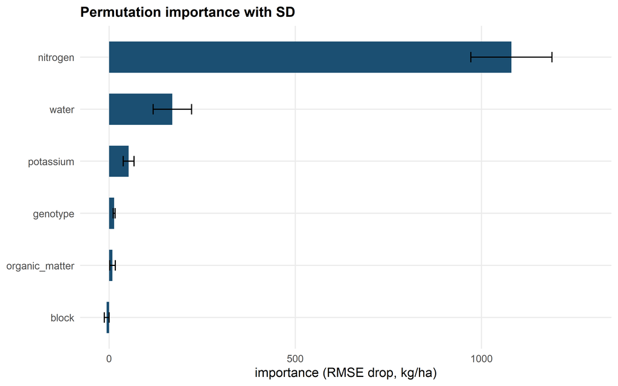

Figure 1: Importance with uncertainty: nitrogen dominates; water and potassium come far behind; block and genotype barely matter because they have few levels and moderate effects.

```r
ggplot(imp, aes(stats::reorder(feature, importance), importance)) +
  geom_col(fill = cores_smf[["primaria"]], width = .6) +
  geom_errorbar(aes(ymin = importance - sd, ymax = importance + sd), width = .2) +
  coord_flip() +
  labs(x = NULL, y = "importance (RMSE drop, kg/ha)",
       title = "Permutation importance with SD") +
  ylim(min(0, min(imp$importance - imp$sd)), max(imp$importance + imp$sd) * 1.08)
```

Profiles answer “how the model changes with the dose”. PDP, ICE and ALE answer the same question through different paths: PDP integrates over the marginal; ICE shows a curve per observation; ALE measures local effects in bins.

```r
pdp_n <- smf_pdp(fit_p5, test_p5, features = "nitrogen", grid_size = 12L)
ale_n <- smf_ale(fit_p5, test_p5, features = "nitrogen", bins = 12L)
ice_n <- smf_ice(fit_p5, test_p5, features = "nitrogen", grid_size = 12L, n = 40L, seed = 7L)
cat("PDP rows:", nrow(pdp_n), "| ICE rows:", nrow(ice_n), "| ALE rows:", nrow(ale_n), "\n")
```

```
PDP rows: 12 | ICE rows: 480 | ALE rows: 12
```

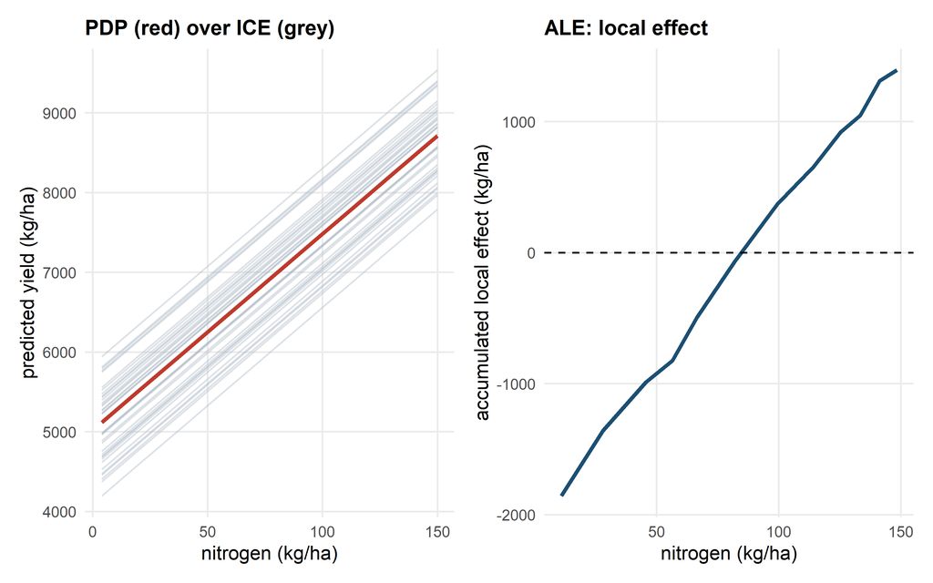

Figure 2: Dependence profiles for nitrogen: the mean PDP and per-plot ICE curves (left) and the accumulated local effect (right). The slope recovers ~25 kg/ha per unit.

```r
p_pdp <- ggplot() +
  geom_line(data = ice_n, aes(value, prediction, group = row_id),
            colour = cores_smf[["claro"]], alpha = .4) +
  geom_line(data = pdp_n, aes(value, prediction), colour = cores_smf[["alerta"]],
            linewidth = 1.1) +
  labs(x = "nitrogen (kg/ha)", y = "predicted yield (kg/ha)",
       title = "PDP (red) over ICE (grey)")
p_ale <- ggplot(ale_n, aes(value, effect)) +
  geom_line(colour = cores_smf[["primaria"]], linewidth = 1.1) +
  geom_hline(yintercept = 0, linetype = "dashed") +
  labs(x = "nitrogen (kg/ha)", y = "accumulated local effect (kg/ha)",
       title = "ALE: local effect")
patchwork::wrap_plots(p_pdp, p_ale)
```

```r
loc <- smf_local_explain(fit_p5, test_p5[1, ], no_out, features = c("nitrogen", "water"))
tab_smf(loc, caption = "Local explanation of the first test plot: contribution of each variable to the difference between prediction and reference.")
```

Local explanation of the first test plot: contribution of each variable to the difference between prediction and reference.

| row_id | feature | original | reference | prediction | reference_prediction | contribution |
| --- | --- | --- | --- | --- | --- | --- |
| 1 | nitrogen | 146.8 | 87.7 | 8692.292 | 7237.908 | 1454.384 |
| 1 | water | 574.8 | 510 | 8692.292 | 8500.909 | 191.383 |

```r
sh <- smf_shap(fit_p5, background = no_out[1:40, ], new_data = test_p5[1:4, ],
               nsim = 20L, seed = 3L)
tab_smf(sh[1:4, c("plot_id", "nitrogen", "water", "organic_matter")],
        caption = "SHAP values for four plots (additive, approximate attribution).")
```

SHAP values for four plots (additive, approximate attribution).

| plot_id | nitrogen | water | organic_matter |
| --- | --- | --- | --- |
| 0 | 1466.345 | 395.061 | 37.264 |
| 0 | -1219.080 | 77.930 | 80.612 |
| 0 | -616.581 | 35.863 | -40.935 |
| 0 | 218.776 | -172.779 | -6.470 |

**NoteInterpretation**

The three tools agree on direction and order: nitrogen dominates, the curve is almost straight with a slope close to the truth (25 kg/ha per unit) and the local explanation balances the books (`contribution = prediction - reference`). Importance **is not cause**: shuffling nitrogen also destroys the correlated structure of the trial; the reading is therefore “the model uses this variable”, not “this variable causes the effect”.

## 1.1 Explanation stability

An explanation from a single fit can be luck. `smf_explanation_stability()` repeats the explanation across folds and measures rank agreement.

```r
spec_cv_p5 <- smf_experiment_spec(
  task = smf_task_spec("regression", "yield"),
  data = smf_data_spec("yield", c("nitrogen", "potassium", "water", "organic_matter",
                                  "block", "genotype"),
                       id_column = "plot_id", categorical = c("block", "genotype")),
  design = smf_design_spec(id_column = "plot_id"),
  preprocessing = smf_preprocess_spec("median"),
  resampling = smf_resampling_spec("kfold", n_splits = 4L, seed = 17L),
  model = smf_model_spec("linear_regression", "stats"),
  metrics = list(smf_metric_spec("rmse")),
  reproducibility = smf_reproducibility_spec(17L)
)
exspec <- smf_explain_spec("permutation", n_repeats = 3L, seed = 44L)
xai_stability <- smf_explanation_stability(spec_cv_p5, no_out, exspec, top_k = 3L)
tab_smf(xai_stability@summary, caption = "Mean importance across folds, with the frequency of a positive signal.")
```

Mean importance across folds, with the frequency of a positive signal.

| feature | mean_importance | sd_importance | cv_importance | positive_fraction | n_folds |
| --- | --- | --- | --- | --- | --- |
| nitrogen | 1146.098 | 90.310 | 0.079 | 1.0 | 4 |
| water | 180.266 | 37.930 | 0.210 | 1.0 | 4 |
| potassium | 100.424 | 15.385 | 0.153 | 1.0 | 4 |
| block | -2.398 | 9.646 | 4.022 | 0.5 | 4 |
| genotype | 17.192 | 16.959 | 0.986 | 1.0 | 4 |
| organic_matter | 8.885 | 6.400 | 0.720 | 1.0 | 4 |

```r
tab_smf(xai_stability@rank_stability, caption = "Rank stability: mean position of each variable across folds.")
```

Rank stability: mean position of each variable across folds.

| feature | mean_rank | sd_rank |
| --- | --- | --- |
| nitrogen | 1.0 | 0.000 |
| water | 2.0 | 0.000 |
| potassium | 3.0 | 0.000 |
| block | 5.5 | 1.000 |
| genotype | 4.5 | 0.577 |
| organic_matter | 5.0 | 0.816 |

**ImportantInterpretation**

With 6 variables and 4 folds, the ranking is stable when `sd_rank` is small and `positive_fraction` is 1. Nitrogen appears at the top in every fold; weak-effect variables swap positions — and that is information, not a defect: unstable explanations must be communicated as unstable.

# 2 Uncertainty with a declared meaning

The package refuses to treat uncertainty types as synonyms. The semantics table is the contract: each interval promises something different, and none is interchangeable.

```r
sem_u <- smf_uncertainty_semantics()
tab_smf(sem_u, caption = "Canonical semantics of interval types: what each promises and under which assumptions.")
```

Canonical semantics of interval types: what each promises and under which assumptions.

| interval_type | target | probability_statement | interchangeable |
| --- | --- | --- | --- |
| confidence | parameter or estimand | repeated-sample procedure | FALSE |
| credible | parameter/latent quantity | posterior probability conditional on model/prior | FALSE |
| prediction | future response | sampling distribution conditional on fitted model | FALSE |
| posterior_predictive | future response | posterior predictive probability | FALSE |
| bootstrap | estimator/statistic | resampling approximation | FALSE |
| conformal | future response or class set | marginal coverage under conformal assumptions | FALSE |

```r
desc_conformal <- smf_uncertainty_descriptor("conformal", "future_response", "conformal",
                                             0.90, "exchangeability")
desc_bootstrap <- smf_uncertainty_descriptor("bootstrap", "estimator", "bootstrap",
                                             0.95, "resampling approximation")
val_con <- smf_uncertainty_validate(desc_conformal)
val_boot <- smf_uncertainty_validate(desc_bootstrap)
desc_tbl <- data.frame(
  label = c(smf_uncertainty_label(desc_conformal), smf_uncertainty_label(desc_bootstrap)),
  valid = c(val_con$valid, val_boot$valid)
)
tab_smf(desc_tbl, caption = "Uncertainty labels: source, target and assumption are part of the name.")
```

Uncertainty labels: source, target and assumption are part of the name.

| label | valid |
| --- | --- |
| conformal 90% [conformal; target=future_response] | TRUE |
| bootstrap 95% [bootstrap; target=estimator] | TRUE |

```r
decomp <- smf_uncertainty_decompose(aleatoric = 0.4, epistemic = 0.6, total = 1.0,
                                    method = "ensemble", identified = TRUE)
print(decomp)
```

```
<sciModelFlowR UncertaintyDecomposition>
  method: ensemble
  identified: TRUE
```

```r
refusal_decomp <- tryCatch(
  smf_uncertainty_decompose(aleatoric = 0.4, epistemic = 0.6, method = "unknown",
                            identified = FALSE),
  error = function(e) conditionMessage(e))
cat("decomposition without identification:", refusal_decomp, "\n")
```

```
decomposition without identification: Aleatoric/epistemic decomposition was requested without an identified decomposition contract.
```

```r
refusal_dist <- tryCatch(
  smf_uncertainty_from_distribution(
    smf_prediction_distribution("parametric",
      list(distribution = "normal", mean = 5000, sd = 300))),
  error = function(e) conditionMessage(e))
cat("distribution without identified decomposition:", refusal_dist, "\n")
```

```
distribution without identified decomposition: This prediction distribution does not expose an identified aleatoric/epistemic decomposition.
```

**WarningTrap**

The message above is a deliberate refusal: the package **does not fabricate** an aleatoric/epistemic decomposition that the object cannot support. Without a procedure that separates the sources (ensemble, replicates, hierarchy), the number would be fiction with a technical appearance.

# 3 Conformal: promised coverage, measured coverage

The conformal guarantee is **marginal and under exchangeability** — in the heteroscedastic trial, that is exactly the kind of promise that must be measured. The split below freezes three roles: training, calibration and untouched test.

```r
complete <- no_out[stats::complete.cases(
  no_out[, c("nitrogen", "potassium", "water", "organic_matter")]), ]
set.seed(20260919)
order_idx <- sample.int(nrow(complete))
i_tr <- order_idx[1:90]; i_cal <- order_idx[91:120]; i_te <- order_idx[121:149]
f_con <- stats::lm(yield ~ nitrogen + potassium + water + organic_matter,
                   data = complete[i_tr, ])
p_cal <- unname(stats::predict(f_con, complete[i_cal, ]))
p_te <- unname(stats::predict(f_con, complete[i_te, ]))
con <- smf_conformal_fit(truth = complete$yield[i_cal], prediction = p_cal,
                         spec = smf_conformal_spec("split", level = 0.90),
                         design = smf_design_spec(id_column = "plot_id"),
                         calibration_ids = complete$plot_id[i_cal],
                         final_test_ids = complete$plot_id[i_te])
inter <- smf_conformal_predict(con, prediction = p_te)
coverage <- smf_conformal_coverage(complete$yield[i_te], inter)
tab_smf(coverage, caption = "Empirical coverage of the 90% conformal interval on the untouched test set.")
```

Empirical coverage of the 90% conformal interval on the untouched test set.

| n | coverage | mean_width | median_width |
| --- | --- | --- | --- |
| 29 | 0.897 | 837.043 | 837.043 |

```r
diag_con <- smf_conformal_diagnose(con, truth = complete$yield[i_te], prediction = inter)
tab_smf(diag_con$summary, caption = "Conformal diagnostics: coverage against the target, with declared tolerance.")
```

Conformal diagnostics: coverage against the target, with declared tolerance.

| n | coverage | mean_width | median_width |
| --- | --- | --- | --- |
| 29 | 0.897 | 837.043 | 837.043 |

```r
tab_smf(data.frame(target = diag_con$target, observed = diag_con$observed,
                   monte_carlo_se = diag_con$monte_carlo_se,
                   tolerance = diag_con$tolerance),
        caption = "Target, observed coverage and the sampling margin of error of coverage.")
```

Target, observed coverage and the sampling margin of error of coverage.

| target | observed | monte_carlo_se | tolerance |
| --- | --- | --- | --- |
| 0.9 | 0.897 | 0.056 | 0.111 |

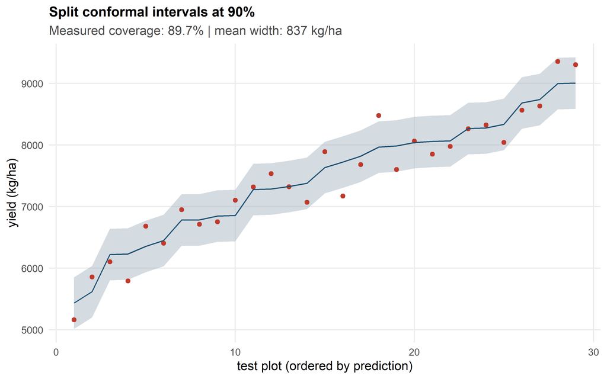

Figure 3: Conformal intervals ordered by prediction: width is constant (split conformal), and coverage is counted on the test set, not presumed.

```r
ord <- order(p_te)
con_df <- data.frame(plot = seq_along(p_te), pred = p_te[ord],
                     lo = inter$.pred_lower[ord], hi = inter$.pred_upper[ord],
                     obs = complete$yield[i_te][ord])
ggplot(con_df, aes(plot, pred)) +
  geom_ribbon(aes(ymin = lo, ymax = hi), fill = cores_smf[["claro"]], alpha = .5) +
  geom_point(aes(y = obs), size = 1.6, colour = cores_smf[["alerta"]]) +
  geom_line(colour = cores_smf[["primaria"]]) +
  labs(x = "test plot (ordered by prediction)", y = "yield (kg/ha)",
       title = "Split conformal intervals at 90%",
       subtitle = paste0("Measured coverage: ", fmt(100 * coverage$coverage, 1),
                         "% | mean width: ", fmt(coverage$mean_width, 0), " kg/ha"))
```

In classification, the target is not an interval but a **set** of labels with guaranteed coverage (APS). The set size is the uncertainty measure.

```r
disease <- ler("disease_binary")
disease$disease <- factor(disease$disease, levels = c(0, 1))
set.seed(20260919)
od <- sample.int(nrow(disease))
tr_c <- od[1:250]; cal_c <- od[251:350]; te_c <- od[351:400]
glm_c <- stats::glm(disease ~ x1 + x2 + x3 + x4, data = disease[tr_c, ],
                    family = stats::binomial())
P_cal <- cbind(`0` = 1 - stats::predict(glm_c, disease[cal_c, ], type = "response"),
               `1` = stats::predict(glm_c, disease[cal_c, ], type = "response"))
P_te_c <- cbind(`0` = 1 - stats::predict(glm_c, disease[te_c, ], type = "response"),
                `1` = stats::predict(glm_c, disease[te_c, ], type = "response"))
aps <- smf_conformal_fit(disease$disease[cal_c], probabilities = P_cal,
                         spec = smf_conformal_spec("aps", level = 0.90))
sets <- smf_conformal_predict(aps, probabilities = P_te_c)
cov_cls <- smf_conformal_coverage(disease$disease[te_c], sets)
tab_smf(cov_cls, caption = "APS conformal sets: coverage and mean set size on the test set.")
```

APS conformal sets: coverage and mean set size on the test set.

| n | coverage | mean_set_size | median_set_size |
| --- | --- | --- | --- |
| 50 | 1 | 2 | 2 |

**NoteInterpretation**

# 4 Transport: does the model work outside the domain?

Block B4 has its own effect and is a natural “external domain” candidate. External validation uses the **already fitted** model, with no refit and no recalibration.

```r
domain_df <- no_out
domain_df$domain <- ifelse(domain_df$block == "B4", "external", "development")
spec_dev <- smf_experiment_spec(
  task = smf_task_spec("regression", "yield"),
  data = smf_data_spec("yield", c("nitrogen", "potassium", "water", "organic_matter"),
                       id_column = "plot_id"),
  design = smf_design_spec(id_column = "plot_id"),
  preprocessing = smf_preprocess_spec("median"),
  resampling = smf_resampling_spec("holdout", train_prop = 0.8, seed = 31L),
  model = smf_model_spec("linear_regression", "stats"),
  metrics = list(smf_metric_spec("rmse"), smf_metric_spec("mae")),
  reproducibility = smf_reproducibility_spec(31L)
)
dev <- domain_df[domain_df$domain == "development", ]
ext <- domain_df[domain_df$domain == "external", ]
fit_dev <- smf_fit_experiment(spec_dev, dev)
val_ext <- smf_external_validate(fit_dev, ext, domain_name = "external")
cmp_ext <- smf_compare_validation_domains(fit_dev, val_ext)
tab_smf(cmp_ext$comparison, caption = "Internal and external metrics side by side: the same model, two domains.")
```

Internal and external metrics side by side: the same model, two domains.

| metric | internal | external | delta | direction |
| --- | --- | --- | --- | --- |
| rmse | 366.263 | 416.144 | 49.881 | minimize |
| mae | 258.757 | 279.990 | 21.234 | minimize |

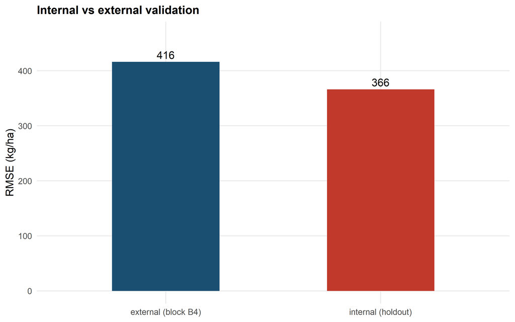

Figure 4: Transport degradation: block B4 has a +60 kg/ha effect and the model fitted on development does not know it — the difference shows up in external validation.

```r
ext_df <- data.frame(
  domain = c("internal (holdout)", "external (block B4)"),
  rmse = c(cmp_ext$internal$value[cmp_ext$internal$metric == "rmse"][1],
           cmp_ext$external$value[cmp_ext$external$metric == "rmse"][1])
)
ggplot(ext_df, aes(domain, rmse, fill = domain)) +
  geom_col(width = .5, show.legend = FALSE) +
  geom_text(aes(label = fmt(rmse, 0)), vjust = -0.4) +
  scale_fill_manual(values = c(cores_smf[["primaria"]], cores_smf[["alerta"]])) +
  labs(x = NULL, y = "RMSE (kg/ha)",
       title = "Internal vs external validation") +
  ylim(0, max(ext_df$rmse) * 1.12)
```

**ImportantInterpretation**

External RMSE is 416 against 366 internally — the difference is the price of transporting a model to a block it never saw. No refit was done: the package measures the transport of the frozen artefact, which is what happens in practice.

# 5 Part 5 exercises

**NoteExercise 5.1 — Importance versus causality**

Nitrogen importance is huge, but water and potassium also enter the simulated truth. Propose an experiment (not computational) that would separate causal effect from association in this trial.

**NoteExercise 5.2 — PDP versus ALE**

Compare the PDP slope with the ALE slope for `nitrogen`. Do both match the truth (25)? In which situation would they diverge?

**NoteExercise 5.3 — Conformal and heteroscedasticity**

Measure conformal coverage **by nitrogen band** (low versus high doses). Does the 90% marginal coverage hold within each band? What does this say about the marginal guarantee?

**NoteExercise 5.4 — Set size as uncertainty**

In APS, order cases by set size. Does size track the predicted probability of the majority class? Build a figure.

**CautionSolutions**

**5.1.** Randomisation: nitrogen doses drawn independently of the other variables (as in the simulation). In observational data, association does not identify the effect; an explicit causal design would be needed.

**5.2.** PDP and ALE coincide here because the model is linear and the variables are independent. With strong interactions or correlated predictors, PDP integrates over unlikely combinations and ALE localises the effect — the curves diverge.

**5.3.** Marginal 90% coverage does not imply 90% within each band: under heteroscedasticity, high doses tend to fall below and low doses above. That is why Part 6 presents **local** conformal (CQR) and per-band reading.